# Module 157

#### Hemi-module gene counts:

416 probesets in hemi-module A.  
82 probesets in hemi-module B.  
Note: While the mapping of probesets to genes is usually one-to-one, some genes are targeted by multiple probesets, some probesets target multiple genes, and some probesets do not target any genes (i.e., the region of the genome they match is no longer considered genic).

#### Contrast SVE:

Signed variance explained (SVE) provides an indication of how similar a set of fold changes are to a gene module’s weight vector. An SVE value of 0.3, for example, indicates that 30% of the variance explained by the entire module set is accounted for by the module in question. Shown here are the SVE values for this module across a compendium of fold changes (contrasts). Extreme SVE values (e.g., > 0.05) indicate that those contrasts specifically induce (orange dots) or specifically repress (blue dots) this module. Examining the experimental conditions being compared in such contrasts (see tables below the figure) may provide insight into the gene module’s function.

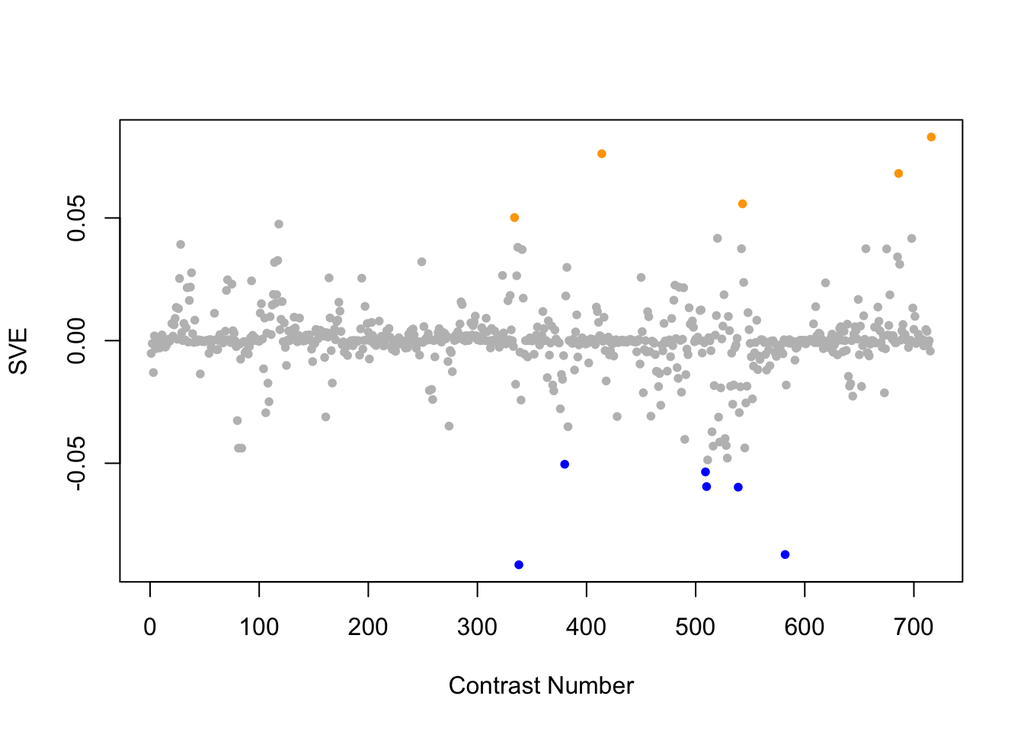

Positive SVE Contrasts:

|  | Contrast.Num | SVE | GEO.GSE | Cond.1 | Cond.2 | Mutation |
| --- | --- | --- | --- | --- | --- | --- |
| GSE10787B.s1t1.vs.s0t1 | 716 | 0.08 | GSE10787 | Microwave (de_Pomerai_10_E5_C.Elegans) | Sham (de_Pomerai_1_S1_C.Elegans) |  |
| GSE29951.s1t1.vs.s0t1 | 414 | 0.08 | GSE29951 | C.elegans MT KO mtl-1,mtl-2(zs1), raised in the absence of Cd, rep1 | C.elegans wild type raised in the absence of Cd, rep1 | mtl-1;mtl-2 |
| GSE12298C.s1t1.vs.s0t1 | 686 | 0.07 | GSE12298 | mefloquine_low_dose-rep1 | mefloquine_control-rep1 |  |
| GSE2180.s4t2.vs.s2t2 | 543 | 0.06 | GSE2180 | pp23-1 | ms23-1 |  |
| GSE38997.s4t2.vs.s1t2 | 334 | 0.05 | GSE38997 | experiment 4 UVC-exposed samples at 24 h 4u24 | experiment 4 control samples at 24 h 4c24 |  |

Negative SVE Contrasts:

|  | Contrast.Num | SVE | GEO.GSE | Cond.1 | Cond.2 | Mutation |
| --- | --- | --- | --- | --- | --- | --- |
| GSE38997.s2t1.vs.s1t1 | 338 | -0.09 | GSE38997 | experiment 4 EtBr-exposed samples at 3 h 4e3 | experiment 4 control samples at 3 h 4c3 |  |
| GSE2180.s2t2.vs.s2t1 | 582 | -0.09 | GSE2180 | ms23-1 | ms0-1 |  |
| GSE2180.s2t2.vs.s1t2 | 539 | -0.06 | GSE2180 | ms23-1 | 23-1 | mex-3(zu155);skn-1(RNAi) |
| GSE2180.s3t1.vs.s1t1 | 510 | -0.06 | GSE2180 | p0-3 | 00B | pie-1(zu154) |
| GSE2180.s2t1.vs.s1t1 | 509 | -0.05 | GSE2180 | ms0-1 | 00B | mex-3(zu155);skn-1(RNAi) |
| GSE34471.s1t1.vs.s0t1 | 380 | -0.05 | GSE34471 | 4uM-Exp1 | 4uM-Con-1 | hrg-2 |

$~$

#### Contrast SVE, Up-Regulated Genes Only:

Calculating SVE for up-regulated and down-regulated genes separately may be more informative in many cases than projecting the up- and down- gene sets together. This is due to the fact that the weight distribution of many modules is highly skewed, indicating that only one of the hemi-modules may be biologically meaningful (i.e., a set of genes are strongly correlated by only a few genes (or none) are strongly anti-correlated to that set.)

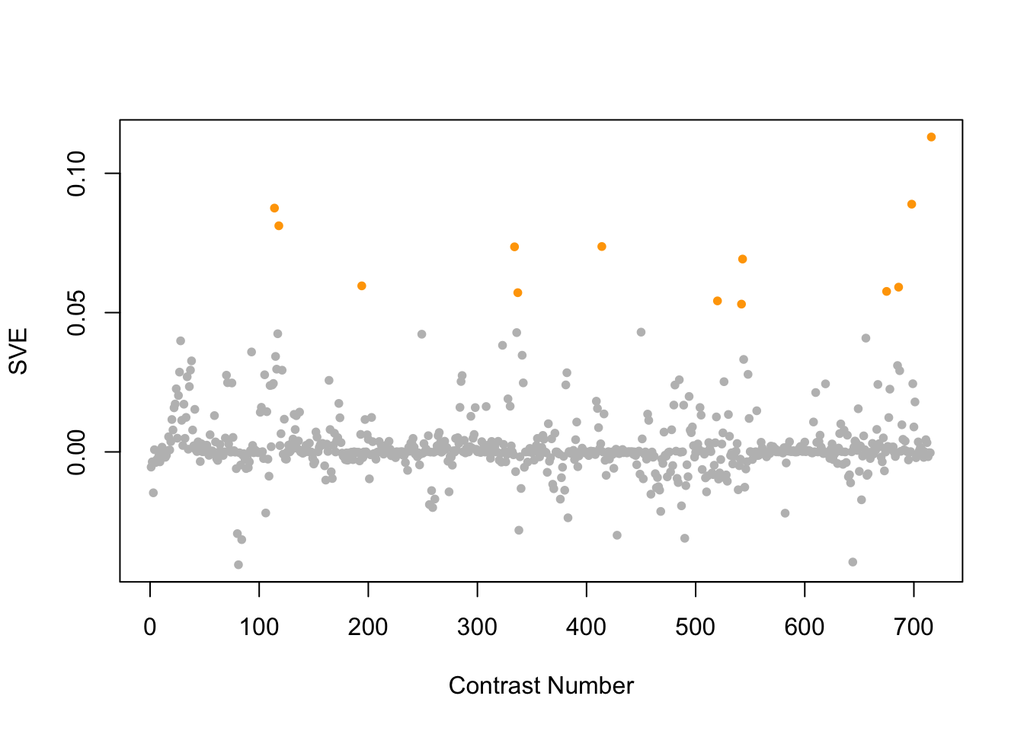

Positive SVE Contrasts:

|  | Contrast.Num | SVE | GEO.GSE | Cond.1 | Cond.2 | Mutation |
| --- | --- | --- | --- | --- | --- | --- |
| GSE10787B.s1t1.vs.s0t1 | 716 | 0.11 | GSE10787 | Microwave (de_Pomerai_10_E5_C.Elegans) | Sham (de_Pomerai_1_S1_C.Elegans) |  |
| GSE11055.s3t4.vs.s2t4 | 698 | 0.09 | GSE11055 | L1 larvae 3 hr after hatching in the absence of food in the alternative starvation buffer M9 | L1 larvae 3 hr after hatching in the absence of food |  |
| GSE54024.s2t1.vs.s5t1 | 114 | 0.09 | GSE54024 | Wild type young adults treated with 0.1mM paraquat, biological rep 1 | ced-4(n1162) young adults, biological rep 1 |  |
| GSE54024.s2t1.vs.s6t1 | 118 | 0.08 | GSE54024 | Wild type young adults treated with 0.1mM paraquat, biological rep 1 | isp-1(qm150) ced-4(n1162) double mutant young adults, biological rep 1 |  |
| GSE29951.s1t1.vs.s0t1 | 414 | 0.07 | GSE29951 | C.elegans MT KO mtl-1,mtl-2(zs1), raised in the absence of Cd, rep1 | C.elegans wild type raised in the absence of Cd, rep1 | mtl-1;mtl-2 |
| GSE38997.s4t2.vs.s1t2 | 334 | 0.07 | GSE38997 | experiment 4 UVC-exposed samples at 24 h 4u24 | experiment 4 control samples at 24 h 4c24 |  |
| GSE2180.s4t2.vs.s2t2 | 543 | 0.07 | GSE2180 | pp23-1 | ms23-1 |  |
| GSE44318.s1t1.vs.s0t1 | 194 | 0.06 | GSE44318 | 13L peptide [SL12] | NGM [SL1] |  |
| GSE12298C.s1t1.vs.s0t1 | 686 | 0.06 | GSE12298 | mefloquine_low_dose-rep1 | mefloquine_control-rep1 |  |
| GSE13258.s4t1.vs.s0t1 | 675 | 0.06 | GSE13258 | alg-1 mutant, biological rep 1 | wild-type, biological rep 1 | alg-1 |
| GSE38997.s4t2.vs.s3t2 | 337 | 0.06 | GSE38997 | experiment 4 UVC-exposed samples at 24 h 4u24 | experiment 4 UVC- and EtBr-exposed samples at 24 h 4eu24 |  |
| GSE2180.s4t7.vs.s3t7 | 520 | 0.05 | GSE2180 | pp101-1 | p101-2 | pal-1(RNAi) |
| GSE2180.s3t2.vs.s2t2 | 542 | 0.05 | GSE2180 | p23-2 | ms23-1 |  |

Negative SVE Contrasts:

|  | Contrast.Num | SVE | GEO.GSE | Cond.1 | Cond.2 | Mutation |
| --- | --- | --- | --- | --- | --- | --- |
| GSE8004.s2t2.vs.s2t1 | 81 | -0.04 | GSE8004 | Larval Reference, biological rep 1 of set 1 | Embryonic Reference, biological rep 1 of set 1 |  |
| GSE16915.s1t1.vs.s3t1 | 644 | -0.04 | GSE16915 | control sample | bio-electrosprayed sample |  |
| GSE6547.s2t2.vs.s0t2 | 84 | -0.03 | GSE6547 | slr-2(ku297) worms at L1 stage, first replicate | N2 (wt) worms at L1 stage, first replicate | sir-2 |
| GSE23528B.s1t4.vs.s1t1 | 490 | -0.03 | GSE23528 | Adult at T38 in CC, time-series experiment 3 | Adult at T26 in CC, time-series experiment 3 |  |
| GSE27677A.s3t1.vs.s0t1 | 428 | -0.03 | GSE27677 | daf-16, Fed , rep 1 | N2, Fed , rep 1 | daf-16 |

$~$

#### Contrast SVE, Down-Regulated Genes Only:

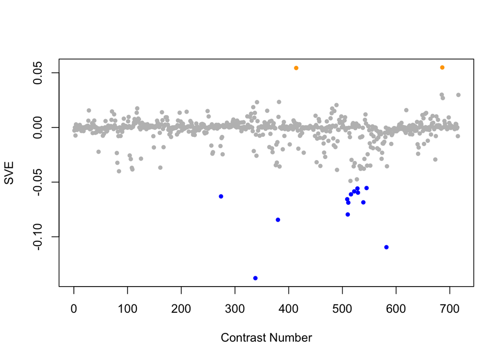

Positive SVE Contrasts:

|  | Contrast.Num | SVE | GEO.GSE | Cond.1 | Cond.2 | Mutation |
| --- | --- | --- | --- | --- | --- | --- |
| GSE12298C.s1t1.vs.s0t1 | 686 | 0.05 | GSE12298 | mefloquine_low_dose-rep1 | mefloquine_control-rep1 |  |
| GSE29951.s1t1.vs.s0t1 | 414 | 0.05 | GSE29951 | C.elegans MT KO mtl-1,mtl-2(zs1), raised in the absence of Cd, rep1 | C.elegans wild type raised in the absence of Cd, rep1 | mtl-1;mtl-2 |
| GSE12298C.s3t1.vs.s0t1 | 685 | 0.03 | GSE12298 | mefloquine_high_dose-rep1 | mefloquine_control-rep1 |  |
| GSE10787B.s1t1.vs.s0t1 | 716 | 0.03 | GSE10787 | Microwave (de_Pomerai_10_E5_C.Elegans) | Sham (de_Pomerai_1_S1_C.Elegans) |  |
| GSE12298C.s2t1.vs.s0t1 | 687 | 0.03 | GSE12298 | mefloquine_mid_dose-rep1 | mefloquine_control-rep1 |  |

Negative SVE Contrasts:

|  | Contrast.Num | SVE | GEO.GSE | Cond.1 | Cond.2 | Mutation |
| --- | --- | --- | --- | --- | --- | --- |
| GSE38997.s2t1.vs.s1t1 | 338 | -0.14 | GSE38997 | experiment 4 EtBr-exposed samples at 3 h 4e3 | experiment 4 control samples at 3 h 4c3 |  |
| GSE2180.s2t2.vs.s2t1 | 582 | -0.11 | GSE2180 | ms23-1 | ms0-1 |  |
| GSE34471.s1t1.vs.s0t1 | 380 | -0.08 | GSE34471 | 4uM-Exp1 | 4uM-Con-1 | hrg-2 |
| GSE2180.s3t1.vs.s1t1 | 510 | -0.08 | GSE2180 | p0-3 | 00B | pie-1(zu154) |
| GSE2180.s4t1.vs.s1t1 | 511 | -0.07 | GSE2180 | pp0-1 | 00B | pie-1(zu154);pal-1(RNAi) |
| GSE2180.s2t2.vs.s1t2 | 539 | -0.07 | GSE2180 | ms23-1 | 23-1 | mex-3(zu155);skn-1(RNAi) |
| GSE2180.s2t1.vs.s1t1 | 509 | -0.07 | GSE2180 | ms0-1 | 00B | mex-3(zu155);skn-1(RNAi) |
| GSE41366B.s1t1.vs.s0t1 | 274 | -0.06 | GSE41366 | low_DDVP-8h_expose-14h_harvest-rep1 | control-8h_expose-14h_harvest-rep1 |  |
| GSE2180.s3t7.vs.s1t7 | 516 | -0.06 | GSE2180 | p101-2 | 101G | pie-1(zu154) |
| GSE2180.s4t9.vs.s1t9 | 529 | -0.06 | GSE2180 | pp143-1 | 143L | pie-1(zu154);pal-1(RNAi) |
| GSE2180.s3t8.vs.s1t8 | 522 | -0.06 | GSE2180 | p122-2 | 122-1 | pie-1(zu154) |
| GSE2180.s3t9.vs.s1t9 | 528 | -0.06 | GSE2180 | p143-2 | 143L | pie-1(zu154) |
| GSE2180.s2t3.vs.s1t3 | 545 | -0.06 | GSE2180 | ms41-1 | 41D | mex-3(zu155);skn-1(RNAi) |

$~$

$~$

#### GO Term Enrichment:

This analysis tests each hemi-module for enrichment of specific GO terms. Only gene-level annotations (e.g., as would be found on the gene’s page in Wormbase) are tested - the hierarchical structure of the GO ontology is not taken into account.

*Note: At least the top two most enriched terms from each GO domain (BP/MF/CC) are shown, even when not statistically significant.*

##### Enriched GO terms: Hemi-module A

| ID | GO.Term | GO Domain | Raw p-value | Adj p-value |
| --- | --- | --- | --- | --- |
| [GO_0006886](http://amigo.geneontology.org/amigo/term/GO:0006886) | intracellular protein transport | BP | 1.20e-10 | 4.37e-07 |
| [GO_0015031](http://amigo.geneontology.org/amigo/term/GO:0015031) | protein transport | BP | 8.48e-10 | 1.55e-06 |
| [GO_0016192](http://amigo.geneontology.org/amigo/term/GO:0016192) | vesicle-mediated transport | BP | 2.66e-09 | 3.23e-06 |
| [GO_0036498](http://amigo.geneontology.org/amigo/term/GO:0036498) | IRE1-mediated unfolded protein response | BP | 1.64e-08 | 1.49e-05 |
| [GO_0032482](http://amigo.geneontology.org/amigo/term/GO:0032482) | Rab protein signal transduction | BP | 1.10e-07 | 7.98e-05 |
| [GO_0008654](http://amigo.geneontology.org/amigo/term/GO:0008654) | phospholipid biosynthetic process | BP | 1.55e-07 | 9.41e-05 |
| [GO_0007186](http://amigo.geneontology.org/amigo/term/GO:0007186) | G protein-coupled receptor signaling pathway | BP | 5.66e-06 | 2.94e-03 |
| [GO_0006465](http://amigo.geneontology.org/amigo/term/GO:0006465) | signal peptide processing | BP | 2.27e-05 | 1.03e-02 |
| [GO_0034314](http://amigo.geneontology.org/amigo/term/GO:0034314) | Arp2/3 complex-mediated actin nucleation | BP | 4.44e-05 | 1.80e-02 |
| [GO_0006621](http://amigo.geneontology.org/amigo/term/GO:0006621) | protein retention in ER lumen | BP | 9.47e-05 | 3.45e-02 |
| [GO_0009792](http://amigo.geneontology.org/amigo/term/GO:0009792) | embryo development ending in birth or egg hatching | BP | 1.34e-04 | 4.44e-02 |
| [GO_0006890](http://amigo.geneontology.org/amigo/term/GO:0006890) | retrograde vesicle-mediated transport, Golgi to ER | BP | 2.16e-04 | 6.56e-02 |
| [GO_0008643](http://amigo.geneontology.org/amigo/term/GO:0008643) | carbohydrate transport | BP | 2.77e-04 | 7.75e-02 |
| [GO_0006888](http://amigo.geneontology.org/amigo/term/GO:0006888) | ER to Golgi vesicle-mediated transport | BP | 4.30e-04 | 9.72e-02 |
| [GO_0006646](http://amigo.geneontology.org/amigo/term/GO:0006646) | phosphatidylethanolamine biosynthetic process | BP | 4.53e-04 | 9.72e-02 |
| [GO_0010631](http://amigo.geneontology.org/amigo/term/GO:0010631) | epithelial cell migration | BP | 4.53e-04 | 9.72e-02 |
| [GO_0016024](http://amigo.geneontology.org/amigo/term/GO:0016024) | CDP-diacylglycerol biosynthetic process | BP | 4.53e-04 | 9.72e-02 |
| [GO_0005525](http://amigo.geneontology.org/amigo/term/GO:0005525) | GTP binding | MF | 6.98e-06 | 1.34e-02 |
| [GO_0003924](http://amigo.geneontology.org/amigo/term/GO:0003924) | GTPase activity | MF | 1.31e-05 | 1.34e-02 |
| [GO_0005789](http://amigo.geneontology.org/amigo/term/GO:0005789) | endoplasmic reticulum membrane | CC | 3.12e-22 | 2.89e-19 |
| [GO_0005783](http://amigo.geneontology.org/amigo/term/GO:0005783) | endoplasmic reticulum | CC | 4.65e-18 | 2.16e-15 |
| [GO_0005794](http://amigo.geneontology.org/amigo/term/GO:0005794) | Golgi apparatus | CC | 1.27e-10 | 3.91e-08 |
| [GO_0005774](http://amigo.geneontology.org/amigo/term/GO:0005774) | vacuolar membrane | CC | 4.46e-06 | 1.02e-03 |
| [GO_0030173](http://amigo.geneontology.org/amigo/term/GO:0030173) | integral component of Golgi membrane | CC | 5.49e-06 | 1.02e-03 |
| [GO_0016020](http://amigo.geneontology.org/amigo/term/GO:0016020) | membrane | CC | 1.05e-05 | 1.63e-03 |
| [GO_0010008](http://amigo.geneontology.org/amigo/term/GO:0010008) | endosome membrane | CC | 2.14e-05 | 2.64e-03 |
| [GO_0005885](http://amigo.geneontology.org/amigo/term/GO:0005885) | Arp2/3 protein complex | CC | 2.27e-05 | 2.64e-03 |
| [GO_0045335](http://amigo.geneontology.org/amigo/term/GO:0045335) | phagocytic vesicle | CC | 3.22e-05 | 2.99e-03 |
| [GO_0055038](http://amigo.geneontology.org/amigo/term/GO:0055038) | recycling endosome membrane | CC | 3.22e-05 | 2.99e-03 |
| [GO_0000502](http://amigo.geneontology.org/amigo/term/GO:0000502) | proteasome complex | CC | 4.45e-05 | 3.76e-03 |
| [GO_0030479](http://amigo.geneontology.org/amigo/term/GO:0030479) | actin cortical patch | CC | 7.81e-05 | 6.04e-03 |
| [GO_0005769](http://amigo.geneontology.org/amigo/term/GO:0005769) | early endosome | CC | 9.45e-05 | 6.75e-03 |
| [GO_0016021](http://amigo.geneontology.org/amigo/term/GO:0016021) | integral component of membrane | CC | 1.48e-04 | 9.81e-03 |
| [GO_0030176](http://amigo.geneontology.org/amigo/term/GO:0030176) | integral component of endoplasmic reticulum membrane | CC | 3.28e-04 | 2.03e-02 |
| [GO_0005801](http://amigo.geneontology.org/amigo/term/GO:0005801) | cis-Golgi network | CC | 7.76e-04 | 4.50e-02 |
| [GO_0008290](http://amigo.geneontology.org/amigo/term/GO:0008290) | F-actin capping protein complex | CC | 8.39e-04 | 4.57e-02 |
| [GO_0000139](http://amigo.geneontology.org/amigo/term/GO:0000139) | Golgi membrane | CC | 8.87e-04 | 4.57e-02 |
| [GO_0005793](http://amigo.geneontology.org/amigo/term/GO:0005793) | endoplasmic reticulum-Golgi intermediate compartment | CC | 9.60e-04 | 4.69e-02 |
| [GO_0016324](http://amigo.geneontology.org/amigo/term/GO:0016324) | apical plasma membrane | CC | 1.10e-03 | 5.05e-02 |
| [GO_0005829](http://amigo.geneontology.org/amigo/term/GO:0005829) | cytosol | CC | 1.14e-03 | 5.05e-02 |
| [GO_0031201](http://amigo.geneontology.org/amigo/term/GO:0031201) | SNARE complex | CC | 2.33e-03 | 8.90e-02 |
| [GO_0005965](http://amigo.geneontology.org/amigo/term/GO:0005965) | protein farnesyltransferase complex | CC | 2.47e-03 | 8.90e-02 |
| [GO_0033181](http://amigo.geneontology.org/amigo/term/GO:0033181) | plasma membrane proton-transporting V-type ATPase complex | CC | 2.47e-03 | 8.90e-02 |
| [GO_0005869](http://amigo.geneontology.org/amigo/term/GO:0005869) | dynactin complex | CC | 2.49e-03 | 8.90e-02 |
| [GO_0008541](http://amigo.geneontology.org/amigo/term/GO:0008541) | proteasome regulatory particle, lid subcomplex | CC | 2.49e-03 | 8.90e-02 |
| [GO_0005768](http://amigo.geneontology.org/amigo/term/GO:0005768) | endosome | CC | 2.67e-03 | 9.18e-02 |
| [GO_0005615](http://amigo.geneontology.org/amigo/term/GO:0005615) | extracellular space | CC | 2.91e-03 | 9.64e-02 |

##### Enriched GO terms: Hemi-module B

| ID | GO.Term | GO Domain | Raw p-value | Adj p-value |
| --- | --- | --- | --- | --- |
| [GO_0006120](http://amigo.geneontology.org/amigo/term/GO:0006120) | mitochondrial electron transport, NADH to ubiquinone | BP | 2.94e-04 | 9.98e-01 |
| [GO_0006614](http://amigo.geneontology.org/amigo/term/GO:0006614) | SRP-dependent cotranslational protein targeting to membrane | BP | 8.12e-04 | 9.98e-01 |
| [GO_0043295](http://amigo.geneontology.org/amigo/term/GO:0043295) | glutathione binding | MF | 2.96e-05 | 6.05e-02 |
| [GO_0030942](http://amigo.geneontology.org/amigo/term/GO:0030942) | endoplasmic reticulum signal peptide binding | MF | 8.86e-05 | 8.26e-02 |
| [GO_0050661](http://amigo.geneontology.org/amigo/term/GO:0050661) | NADP binding | MF | 1.21e-04 | 8.26e-02 |
| [GO_0048256](http://amigo.geneontology.org/amigo/term/GO:0048256) | flap endonuclease activity | MF | 1.77e-04 | 9.02e-02 |
| [GO_0016021](http://amigo.geneontology.org/amigo/term/GO:0016021) | integral component of membrane | CC | 1.07e-05 | 9.94e-03 |
| [GO_0005747](http://amigo.geneontology.org/amigo/term/GO:0005747) | mitochondrial respiratory chain complex I | CC | 3.00e-05 | 1.38e-02 |
| [GO_0005739](http://amigo.geneontology.org/amigo/term/GO:0005739) | mitochondrion | CC | 5.15e-05 | 1.38e-02 |
| [GO_0005737](http://amigo.geneontology.org/amigo/term/GO:0005737) | cytoplasm | CC | 6.14e-05 | 1.38e-02 |
| [GO_0016020](http://amigo.geneontology.org/amigo/term/GO:0016020) | membrane | CC | 7.43e-05 | 1.38e-02 |
| [GO_0005759](http://amigo.geneontology.org/amigo/term/GO:0005759) | mitochondrial matrix | CC | 2.62e-04 | 4.06e-02 |
| [GO_0005829](http://amigo.geneontology.org/amigo/term/GO:0005829) | cytosol | CC | 4.32e-04 | 5.43e-02 |
| [GO_0005741](http://amigo.geneontology.org/amigo/term/GO:0005741) | mitochondrial outer membrane | CC | 4.68e-04 | 5.43e-02 |
| [GO_0005786](http://amigo.geneontology.org/amigo/term/GO:0005786) | signal recognition particle, endoplasmic reticulum targeting | CC | 6.11e-04 | 6.30e-02 |

$~$

$~$

#### Tissue Enrichment:

This analysis tests each hemi-module for enrichment of genes associated with anatomy terms. Negative enrichment scores indicate fewer hemi-module genes than expected by random chance were associated with the anatomy term in question.

##### Enriched tissues: Hemi-module A

| ID | Anatomy.Term | Definition | Raw p-value | Adj p-value |
| --- | --- | --- | --- | --- |
| [WBbt_0005747](https://wormbase.org/species/all/anatomy_term/WBbt:0005747) | reproductive system |  | 3.74e-10 | 9.09e-07 |
| [WBbt_0005813](https://wormbase.org/species/all/anatomy_term/WBbt:0005813) | body wall musculature | Longitudinal bands of muscle cells surrounding animal body, with one band running in each quadrant of the body, regulated contraction and relaxation of these muscles cause locomotion. | 2.88e-08 | 3.50e-05 |
| [WBbt_0005772](https://wormbase.org/species/all/anatomy_term/WBbt:0005772) | intestine | A chain of very large cuboidal cells forming a wide central lumen in which food arrives from the posterior pharynx, is digested, and from which waste products proceed to the rectum. Intestinal rings f… | 2.83e-06 | 2.29e-03 |
| [WBbt_0005735](https://wormbase.org/species/all/anatomy_term/WBbt:0005735) | nervous system | Complement of nervous tissue (neurones, nerves, receptors and support cells) serving to detect, relay and coordinate information about an animal’s internal and external environments and to initiate an… | 4.10e-06 | 2.49e-03 |
| [WBbt_0003681](https://wormbase.org/species/all/anatomy_term/WBbt:0003681) | pharynx | the feeding organ, a neuro-muscular pump in the head of the animal, used to ingest food, bacteria suspended in liquid, filter them out, grind them up and transport posteriorly into the instestine. | 8.08e-06 | 3.54e-03 |
| [WBbt_0005300](https://wormbase.org/species/all/anatomy_term/WBbt:0005300) | ventral cord neuron | neuron with cell body associated with the ventral nerve cord. | 8.74e-06 | 3.54e-03 |
| [WBbt_0003822](https://wormbase.org/species/all/anatomy_term/WBbt:0003822) | mu_int_R | right intestinal muscle cell, attach to intestine and body wall anterior to anus | 2.12e-05 | 6.44e-03 |
| [WBbt_0003833](https://wormbase.org/species/all/anatomy_term/WBbt:0003833) | mu_int_L | left intestinal muscle cell, attach to intestine and body wall anterior to anus | 2.12e-05 | 6.44e-03 |
| [WBbt_0005733](https://wormbase.org/species/all/anatomy_term/WBbt:0005733) | hypodermis | Epidermal layer. | 2.77e-05 | 6.84e-03 |
| [WBbt_0006748](https://wormbase.org/species/all/anatomy_term/WBbt:0006748) | vulva | female genital. | 2.81e-05 | 6.84e-03 |
| [WBbt_0005821](https://wormbase.org/species/all/anatomy_term/WBbt:0005821) | vulval muscle | muscle associated with hermaphrodite vulva. | 8.01e-05 | 1.77e-02 |
| [WBbt_0005828](https://wormbase.org/species/all/anatomy_term/WBbt:0005828) | gonadal sheath cell | five pairs of thin gonadal sheath cells form a single layer covering the germ line component of each arm, each pair occupying a stereotyped position along the gonad proximal-distal axis. | 2.12e-04 | 4.30e-02 |
| [WBbt_0005319](https://wormbase.org/species/all/anatomy_term/WBbt:0005319) | spermatheca | an accordion-like tube that contains sperm and is the site of oocyte fertilization. | 4.46e-04 | 8.34e-02 |

##### Enriched tissues: Hemi-module B

No significant annotations.

$~$

$~$

#### HOMER promoter motif enrichment:

This analysis tests each hemi-module for enrichment of 108 known *C. elegans* transcription factor binding site motifs (see [108 CE motifs](https://katiepod.github.io//all.worm.motifs.html)) using the HOMER (Hypergeometric Optimization of Motif EnRichment) software (see [PMID:20513432](https://pubmed.ncbi.nlm.nih.gov/20513432)). HOMER was run using default parameters on sequences 1 kb upstream of the transcription start site.

##### Motif enrichment: Hemi-module A

Total target sequences = 376  
Total background sequences = 38235  
* - possible false positive

Rank

Motif

P-value

log P-pvalue

% of Targets

% of Background

STD(Bg STD)

Best Match/Details

Motif File

1

[figure not shown]

1e-17

-4.080e+01

26.60%

10.44%

298.9bp (365.5bp)

skn-1/MA0547.1/Jaspar(0.550)  
[More Information](https://katiepod.github.io/HomerResults/m157_a_hemi_genes.txt.out.1kb/homerResults/motif1.info.html) | [Similar Motifs Found](https://katiepod.github.io/HomerResults/m157_a_hemi_genes.txt.out.1kb/homerResults/motif1.similar.html)

[motif file (matrix)](https://katiepod.github.io/HomerResults/m157_a_hemi_genes.txt.out.1kb/homerResults/motif1.motif)

2

[figure not shown]

1e-13

-3.046e+01

25.80%

11.69%

260.5bp (362.5bp)

eor-1/MA0543.1/Jaspar(0.747)  
[More Information](https://katiepod.github.io/HomerResults/m157_a_hemi_genes.txt.out.1kb/homerResults/motif2.info.html) | [Similar Motifs Found](https://katiepod.github.io/HomerResults/m157_a_hemi_genes.txt.out.1kb/homerResults/motif2.similar.html)

[motif file (matrix)](https://katiepod.github.io/HomerResults/m157_a_hemi_genes.txt.out.1kb/homerResults/motif2.motif)

3

[figure not shown]

1e-12

-2.837e+01

68.09%

49.65%

298.8bp (364.9bp)

ceh-28/MA1445.1/Jaspar(0.887)  
[More Information](https://katiepod.github.io/HomerResults/m157_a_hemi_genes.txt.out.1kb/homerResults/motif3.info.html) | [Similar Motifs Found](https://katiepod.github.io/HomerResults/m157_a_hemi_genes.txt.out.1kb/homerResults/motif3.similar.html)

[motif file (matrix)](https://katiepod.github.io/HomerResults/m157_a_hemi_genes.txt.out.1kb/homerResults/motif3.motif)

4

[figure not shown]

1e-12

-2.828e+01

9.57%

2.20%

309.5bp (325.2bp)

DPL-1(E2F)/cElegans-Adult-ChIP-Seq(modEncode)/Homer(0.584)  
[More Information](https://katiepod.github.io/HomerResults/m157_a_hemi_genes.txt.out.1kb/homerResults/motif4.info.html) | [Similar Motifs Found](https://katiepod.github.io/HomerResults/m157_a_hemi_genes.txt.out.1kb/homerResults/motif4.similar.html)

[motif file (matrix)](https://katiepod.github.io/HomerResults/m157_a_hemi_genes.txt.out.1kb/homerResults/motif4.motif)

5

[figure not shown]

1e-12

-2.824e+01

27.39%

13.30%

309.6bp (347.2bp)

blmp-1/MA0537.1/Jaspar(0.710)  
[More Information](https://katiepod.github.io/HomerResults/m157_a_hemi_genes.txt.out.1kb/homerResults/motif5.info.html) | [Similar Motifs Found](https://katiepod.github.io/HomerResults/m157_a_hemi_genes.txt.out.1kb/homerResults/motif5.similar.html)

[motif file (matrix)](https://katiepod.github.io/HomerResults/m157_a_hemi_genes.txt.out.1kb/homerResults/motif5.motif)

6 *

[figure not shown]

1e-11

-2.609e+01

29.26%

15.20%

284.0bp (361.9bp)

blmp-1/MA0537.1/Jaspar(0.598)  
[More Information](https://katiepod.github.io/HomerResults/m157_a_hemi_genes.txt.out.1kb/homerResults/motif6.info.html) | [Similar Motifs Found](https://katiepod.github.io/HomerResults/m157_a_hemi_genes.txt.out.1kb/homerResults/motif6.similar.html)

[motif file (matrix)](https://katiepod.github.io/HomerResults/m157_a_hemi_genes.txt.out.1kb/homerResults/motif6.motif)

7 *

[figure not shown]

1e-10

-2.440e+01

5.32%

0.74%

241.8bp (357.3bp)

POL004.1_CCAAT-box/Jaspar(0.589)  
[More Information](https://katiepod.github.io/HomerResults/m157_a_hemi_genes.txt.out.1kb/homerResults/motif7.info.html) | [Similar Motifs Found](https://katiepod.github.io/HomerResults/m157_a_hemi_genes.txt.out.1kb/homerResults/motif7.similar.html)

[motif file (matrix)](https://katiepod.github.io/HomerResults/m157_a_hemi_genes.txt.out.1kb/homerResults/motif7.motif)

8 *

[figure not shown]

1e-10

-2.384e+01

6.91%

1.36%

289.5bp (370.2bp)

DPL-1(E2F)/cElegans-Adult-ChIP-Seq(modEncode)/Homer(0.657)  
[More Information](https://katiepod.github.io/HomerResults/m157_a_hemi_genes.txt.out.1kb/homerResults/motif8.info.html) | [Similar Motifs Found](https://katiepod.github.io/HomerResults/m157_a_hemi_genes.txt.out.1kb/homerResults/motif8.similar.html)

[motif file (matrix)](https://katiepod.github.io/HomerResults/m157_a_hemi_genes.txt.out.1kb/homerResults/motif8.motif)

9 *

[figure not shown]

1e-10

-2.371e+01

5.32%

0.77%

282.7bp (318.5bp)

cebp-1/MA1444.1/Jaspar(0.790)  
[More Information](https://katiepod.github.io/HomerResults/m157_a_hemi_genes.txt.out.1kb/homerResults/motif9.info.html) | [Similar Motifs Found](https://katiepod.github.io/HomerResults/m157_a_hemi_genes.txt.out.1kb/homerResults/motif9.similar.html)

[motif file (matrix)](https://katiepod.github.io/HomerResults/m157_a_hemi_genes.txt.out.1kb/homerResults/motif9.motif)

10 *

[figure not shown]

1e-10

-2.329e+01

10.11%

2.91%

284.7bp (312.6bp)

SD0002.1_at_AC_acceptor/Jaspar(0.688)  
[More Information](https://katiepod.github.io/HomerResults/m157_a_hemi_genes.txt.out.1kb/homerResults/motif10.info.html) | [Similar Motifs Found](https://katiepod.github.io/HomerResults/m157_a_hemi_genes.txt.out.1kb/homerResults/motif10.similar.html)

[motif file (matrix)](https://katiepod.github.io/HomerResults/m157_a_hemi_genes.txt.out.1kb/homerResults/motif10.motif)

11 *

[figure not shown]

1e-10

-2.309e+01

10.11%

2.94%

263.6bp (357.3bp)

PHA-4(Forkhead)/cElegans-Embryos-PHA4-ChIP-Seq(modEncode)/Homer(0.814)  
[More Information](https://katiepod.github.io/HomerResults/m157_a_hemi_genes.txt.out.1kb/homerResults/motif11.info.html) | [Similar Motifs Found](https://katiepod.github.io/HomerResults/m157_a_hemi_genes.txt.out.1kb/homerResults/motif11.similar.html)

[motif file (matrix)](https://katiepod.github.io/HomerResults/m157_a_hemi_genes.txt.out.1kb/homerResults/motif11.motif)

12 *

[figure not shown]

1e-9

-2.298e+01

5.32%

0.80%

273.8bp (284.4bp)

MF0004.1_Nuclear_Receptor_class/Jaspar(0.601)  
[More Information](https://katiepod.github.io/HomerResults/m157_a_hemi_genes.txt.out.1kb/homerResults/motif12.info.html) | [Similar Motifs Found](https://katiepod.github.io/HomerResults/m157_a_hemi_genes.txt.out.1kb/homerResults/motif12.similar.html)

[motif file (matrix)](https://katiepod.github.io/HomerResults/m157_a_hemi_genes.txt.out.1kb/homerResults/motif12.motif)

13 *

[figure not shown]

1e-9

-2.261e+01

6.91%

1.45%

289.4bp (358.1bp)

MF0002.1_bZIP_CREB/G-box-like_subclass/Jaspar(0.606)  
[More Information](https://katiepod.github.io/HomerResults/m157_a_hemi_genes.txt.out.1kb/homerResults/motif13.info.html) | [Similar Motifs Found](https://katiepod.github.io/HomerResults/m157_a_hemi_genes.txt.out.1kb/homerResults/motif13.similar.html)

[motif file (matrix)](https://katiepod.github.io/HomerResults/m157_a_hemi_genes.txt.out.1kb/homerResults/motif13.motif)

14 *

[figure not shown]

1e-9

-2.089e+01

37.77%

23.65%

288.1bp (336.7bp)

elt-2/MA1701.1/Jaspar(0.657)  
[More Information](https://katiepod.github.io/HomerResults/m157_a_hemi_genes.txt.out.1kb/homerResults/motif14.info.html) | [Similar Motifs Found](https://katiepod.github.io/HomerResults/m157_a_hemi_genes.txt.out.1kb/homerResults/motif14.similar.html)

[motif file (matrix)](https://katiepod.github.io/HomerResults/m157_a_hemi_genes.txt.out.1kb/homerResults/motif14.motif)

15 *

[figure not shown]

1e-8

-2.064e+01

7.18%

1.72%

328.3bp (385.3bp)

cebp-1/MA1444.1/Jaspar(0.656)  
[More Information](https://katiepod.github.io/HomerResults/m157_a_hemi_genes.txt.out.1kb/homerResults/motif15.info.html) | [Similar Motifs Found](https://katiepod.github.io/HomerResults/m157_a_hemi_genes.txt.out.1kb/homerResults/motif15.similar.html)

[motif file (matrix)](https://katiepod.github.io/HomerResults/m157_a_hemi_genes.txt.out.1kb/homerResults/motif15.motif)

16 *

[figure not shown]

1e-8

-2.052e+01

4.79%

0.74%

274.3bp (331.0bp)

PQM-1(?)/cElegans-L3-ChIP-Seq(modEncode)/Homer(0.702)  
[More Information](https://katiepod.github.io/HomerResults/m157_a_hemi_genes.txt.out.1kb/homerResults/motif16.info.html) | [Similar Motifs Found](https://katiepod.github.io/HomerResults/m157_a_hemi_genes.txt.out.1kb/homerResults/motif16.similar.html)

[motif file (matrix)](https://katiepod.github.io/HomerResults/m157_a_hemi_genes.txt.out.1kb/homerResults/motif16.motif)

17 *

[figure not shown]

1e-8

-2.042e+01

2.93%

0.21%

256.7bp (323.1bp)

blmp-1/MA0537.1/Jaspar(0.571)  
[More Information](https://katiepod.github.io/HomerResults/m157_a_hemi_genes.txt.out.1kb/homerResults/motif17.info.html) | [Similar Motifs Found](https://katiepod.github.io/HomerResults/m157_a_hemi_genes.txt.out.1kb/homerResults/motif17.similar.html)

[motif file (matrix)](https://katiepod.github.io/HomerResults/m157_a_hemi_genes.txt.out.1kb/homerResults/motif17.motif)

18 *

[figure not shown]

1e-8

-2.012e+01

62.23%

46.86%

278.2bp (340.2bp)

eor-1/MA0543.1/Jaspar(0.807)  
[More Information](https://katiepod.github.io/HomerResults/m157_a_hemi_genes.txt.out.1kb/homerResults/motif18.info.html) | [Similar Motifs Found](https://katiepod.github.io/HomerResults/m157_a_hemi_genes.txt.out.1kb/homerResults/motif18.similar.html)

[motif file (matrix)](https://katiepod.github.io/HomerResults/m157_a_hemi_genes.txt.out.1kb/homerResults/motif18.motif)

19 *

[figure not shown]

1e-8

-1.924e+01

1.86%

0.05%

168.0bp (248.5bp)

elt-6/MA1439.1/Jaspar(0.548)  
[More Information](https://katiepod.github.io/HomerResults/m157_a_hemi_genes.txt.out.1kb/homerResults/motif19.info.html) | [Similar Motifs Found](https://katiepod.github.io/HomerResults/m157_a_hemi_genes.txt.out.1kb/homerResults/motif19.similar.html)

[motif file (matrix)](https://katiepod.github.io/HomerResults/m157_a_hemi_genes.txt.out.1kb/homerResults/motif19.motif)

20 *

[figure not shown]

1e-8

-1.896e+01

18.62%

8.98%

338.3bp (367.4bp)

pqm-1/MA1703.1/Jaspar(0.586)  
[More Information](https://katiepod.github.io/HomerResults/m157_a_hemi_genes.txt.out.1kb/homerResults/motif20.info.html) | [Similar Motifs Found](https://katiepod.github.io/HomerResults/m157_a_hemi_genes.txt.out.1kb/homerResults/motif20.similar.html)

[motif file (matrix)](https://katiepod.github.io/HomerResults/m157_a_hemi_genes.txt.out.1kb/homerResults/motif20.motif)

21 *

[figure not shown]

1e-8

-1.895e+01

9.57%

3.12%

257.3bp (322.8bp)

efl-1/MA0541.1/Jaspar(0.568)  
[More Information](https://katiepod.github.io/HomerResults/m157_a_hemi_genes.txt.out.1kb/homerResults/motif21.info.html) | [Similar Motifs Found](https://katiepod.github.io/HomerResults/m157_a_hemi_genes.txt.out.1kb/homerResults/motif21.similar.html)

[motif file (matrix)](https://katiepod.github.io/HomerResults/m157_a_hemi_genes.txt.out.1kb/homerResults/motif21.motif)

22 *

[figure not shown]

1e-7

-1.822e+01

7.45%

2.07%

258.3bp (331.5bp)

POL012.1_TATA-Box/Jaspar(0.540)  
[More Information](https://katiepod.github.io/HomerResults/m157_a_hemi_genes.txt.out.1kb/homerResults/motif22.info.html) | [Similar Motifs Found](https://katiepod.github.io/HomerResults/m157_a_hemi_genes.txt.out.1kb/homerResults/motif22.similar.html)

[motif file (matrix)](https://katiepod.github.io/HomerResults/m157_a_hemi_genes.txt.out.1kb/homerResults/motif22.motif)

23 *

[figure not shown]

1e-7

-1.772e+01

5.05%

1.00%

273.6bp (348.2bp)

ceh-22/MA0264.1/Jaspar(0.582)  
[More Information](https://katiepod.github.io/HomerResults/m157_a_hemi_genes.txt.out.1kb/homerResults/motif23.info.html) | [Similar Motifs Found](https://katiepod.github.io/HomerResults/m157_a_hemi_genes.txt.out.1kb/homerResults/motif23.similar.html)

[motif file (matrix)](https://katiepod.github.io/HomerResults/m157_a_hemi_genes.txt.out.1kb/homerResults/motif23.motif)

24 *

[figure not shown]

1e-7

-1.619e+01

4.52%

0.88%

263.0bp (363.3bp)

MF0010.1_Homeobox_class/Jaspar(0.590)  
[More Information](https://katiepod.github.io/HomerResults/m157_a_hemi_genes.txt.out.1kb/homerResults/motif24.info.html) | [Similar Motifs Found](https://katiepod.github.io/HomerResults/m157_a_hemi_genes.txt.out.1kb/homerResults/motif24.similar.html)

[motif file (matrix)](https://katiepod.github.io/HomerResults/m157_a_hemi_genes.txt.out.1kb/homerResults/motif24.motif)

25 *

[figure not shown]

1e-6

-1.585e+01

1.06%

0.01%

245.2bp (2.2bp)

lin-54/MA1450.1/Jaspar(0.516)  
[More Information](https://katiepod.github.io/HomerResults/m157_a_hemi_genes.txt.out.1kb/homerResults/motif25.info.html) | [Similar Motifs Found](https://katiepod.github.io/HomerResults/m157_a_hemi_genes.txt.out.1kb/homerResults/motif25.similar.html)

[motif file (matrix)](https://katiepod.github.io/HomerResults/m157_a_hemi_genes.txt.out.1kb/homerResults/motif25.motif)

26 *

[figure not shown]

1e-6

-1.498e+01

14.89%

7.23%

246.2bp (334.5bp)

MF0011.1_HMG_class/Jaspar(0.538)  
[More Information](https://katiepod.github.io/HomerResults/m157_a_hemi_genes.txt.out.1kb/homerResults/motif26.info.html) | [Similar Motifs Found](https://katiepod.github.io/HomerResults/m157_a_hemi_genes.txt.out.1kb/homerResults/motif26.similar.html)

[motif file (matrix)](https://katiepod.github.io/HomerResults/m157_a_hemi_genes.txt.out.1kb/homerResults/motif26.motif)

27 *

[figure not shown]

1e-5

-1.318e+01

2.39%

0.28%

232.0bp (346.7bp)

unc-30/MA1443.1/Jaspar(0.611)  
[More Information](https://katiepod.github.io/HomerResults/m157_a_hemi_genes.txt.out.1kb/homerResults/motif27.info.html) | [Similar Motifs Found](https://katiepod.github.io/HomerResults/m157_a_hemi_genes.txt.out.1kb/homerResults/motif27.similar.html)

[motif file (matrix)](https://katiepod.github.io/HomerResults/m157_a_hemi_genes.txt.out.1kb/homerResults/motif27.motif)

28 *

[figure not shown]

1e-5

-1.280e+01

14.36%

7.38%

277.1bp (321.3bp)

POL012.1_TATA-Box/Jaspar(0.667)  
[More Information](https://katiepod.github.io/HomerResults/m157_a_hemi_genes.txt.out.1kb/homerResults/motif28.info.html) | [Similar Motifs Found](https://katiepod.github.io/HomerResults/m157_a_hemi_genes.txt.out.1kb/homerResults/motif28.similar.html)

[motif file (matrix)](https://katiepod.github.io/HomerResults/m157_a_hemi_genes.txt.out.1kb/homerResults/motif28.motif)

29 *

[figure not shown]

1e-5

-1.235e+01

12.77%

6.34%

273.3bp (321.0bp)

MF0011.1_HMG_class/Jaspar(0.536)  
[More Information](https://katiepod.github.io/HomerResults/m157_a_hemi_genes.txt.out.1kb/homerResults/motif29.info.html) | [Similar Motifs Found](https://katiepod.github.io/HomerResults/m157_a_hemi_genes.txt.out.1kb/homerResults/motif29.similar.html)

[motif file (matrix)](https://katiepod.github.io/HomerResults/m157_a_hemi_genes.txt.out.1kb/homerResults/motif29.motif)

30 *

[figure not shown]

1e-4

-1.150e+01

20.74%

12.72%

251.6bp (340.5bp)

daf-12/MA0538.1/Jaspar(0.823)  
[More Information](https://katiepod.github.io/HomerResults/m157_a_hemi_genes.txt.out.1kb/homerResults/motif30.info.html) | [Similar Motifs Found](https://katiepod.github.io/HomerResults/m157_a_hemi_genes.txt.out.1kb/homerResults/motif30.similar.html)

[motif file (matrix)](https://katiepod.github.io/HomerResults/m157_a_hemi_genes.txt.out.1kb/homerResults/motif30.motif)

31 *

[figure not shown]

1e-4

-1.001e+01

13.03%

7.16%

275.5bp (364.1bp)

MF0003.1_REL_class/Jaspar(0.609)  
[More Information](https://katiepod.github.io/HomerResults/m157_a_hemi_genes.txt.out.1kb/homerResults/motif31.info.html) | [Similar Motifs Found](https://katiepod.github.io/HomerResults/m157_a_hemi_genes.txt.out.1kb/homerResults/motif31.similar.html)

[motif file (matrix)](https://katiepod.github.io/HomerResults/m157_a_hemi_genes.txt.out.1kb/homerResults/motif31.motif)

32 *

[figure not shown]

1e-3

-8.086e+00

0.80%

0.03%

195.7bp (344.9bp)

MF0003.1_REL_class/Jaspar(0.548)  
[More Information](https://katiepod.github.io/HomerResults/m157_a_hemi_genes.txt.out.1kb/homerResults/motif32.info.html) | [Similar Motifs Found](https://katiepod.github.io/HomerResults/m157_a_hemi_genes.txt.out.1kb/homerResults/motif32.similar.html)

[motif file (matrix)](https://katiepod.github.io/HomerResults/m157_a_hemi_genes.txt.out.1kb/homerResults/motif32.motif)

33 *

[figure not shown]

1e-3

-7.158e+00

3.72%

1.35%

222.7bp (347.2bp)

POL004.1_CCAAT-box/Jaspar(0.571)  
[More Information](https://katiepod.github.io/HomerResults/m157_a_hemi_genes.txt.out.1kb/homerResults/motif33.info.html) | [Similar Motifs Found](https://katiepod.github.io/HomerResults/m157_a_hemi_genes.txt.out.1kb/homerResults/motif33.similar.html)

[motif file (matrix)](https://katiepod.github.io/HomerResults/m157_a_hemi_genes.txt.out.1kb/homerResults/motif33.motif)

34 *

[figure not shown]

1e-3

-6.929e+00

2.93%

0.93%

235.5bp (305.2bp)

SD0001.1_at_AC_acceptor/Jaspar(0.500)  
[More Information](https://katiepod.github.io/HomerResults/m157_a_hemi_genes.txt.out.1kb/homerResults/motif34.info.html) | [Similar Motifs Found](https://katiepod.github.io/HomerResults/m157_a_hemi_genes.txt.out.1kb/homerResults/motif34.similar.html)

[motif file (matrix)](https://katiepod.github.io/HomerResults/m157_a_hemi_genes.txt.out.1kb/homerResults/motif34.motif)

35 *

[figure not shown]

1e-1

-4.550e+00

98.94%

96.95%

283.3bp (330.2bp)

skn-1/MA0547.1/Jaspar(0.619)  
[More Information](https://katiepod.github.io/HomerResults/m157_a_hemi_genes.txt.out.1kb/homerResults/motif35.info.html) | [Similar Motifs Found](https://katiepod.github.io/HomerResults/m157_a_hemi_genes.txt.out.1kb/homerResults/motif35.similar.html)

[motif file (matrix)](https://katiepod.github.io/HomerResults/m157_a_hemi_genes.txt.out.1kb/homerResults/motif35.motif)

##### Motif enrichment: Hemi-module B

Total target sequences = 72  
Total background sequences = 37413  
* - possible false positive

Rank

Motif

P-value

log P-pvalue

% of Targets

% of Background

STD(Bg STD)

Best Match/Details

Motif File

1 *

[figure not shown]

1e-9

-2.111e+01

8.33%

0.12%

272.8bp (297.7bp)

ceh-28/MA1445.1/Jaspar(0.511)  
[More Information](https://katiepod.github.io/HomerResults/m157_b_hemi_genes.txt.out.1kb/homerResults/motif1.info.html) | [Similar Motifs Found](https://katiepod.github.io/HomerResults/m157_b_hemi_genes.txt.out.1kb/homerResults/motif1.similar.html)

[motif file (matrix)](https://katiepod.github.io/HomerResults/m157_b_hemi_genes.txt.out.1kb/homerResults/motif1.motif)

2 *

[figure not shown]

1e-9

-2.086e+01

11.11%

0.41%

150.0bp (306.0bp)

PL0012.1_hlh-2::hlh-8/Jaspar(0.512)  
[More Information](https://katiepod.github.io/HomerResults/m157_b_hemi_genes.txt.out.1kb/homerResults/motif2.info.html) | [Similar Motifs Found](https://katiepod.github.io/HomerResults/m157_b_hemi_genes.txt.out.1kb/homerResults/motif2.similar.html)

[motif file (matrix)](https://katiepod.github.io/HomerResults/m157_b_hemi_genes.txt.out.1kb/homerResults/motif2.motif)

3 *

[figure not shown]

1e-8

-2.013e+01

13.89%

0.93%

281.3bp (306.7bp)

lin-54/MA1450.1/Jaspar(0.646)  
[More Information](https://katiepod.github.io/HomerResults/m157_b_hemi_genes.txt.out.1kb/homerResults/motif3.info.html) | [Similar Motifs Found](https://katiepod.github.io/HomerResults/m157_b_hemi_genes.txt.out.1kb/homerResults/motif3.similar.html)

[motif file (matrix)](https://katiepod.github.io/HomerResults/m157_b_hemi_genes.txt.out.1kb/homerResults/motif3.motif)

4 *

[figure not shown]

1e-8

-2.010e+01

8.33%

0.15%

183.9bp (303.8bp)

cebp-1/MA1444.1/Jaspar(0.748)  
[More Information](https://katiepod.github.io/HomerResults/m157_b_hemi_genes.txt.out.1kb/homerResults/motif4.info.html) | [Similar Motifs Found](https://katiepod.github.io/HomerResults/m157_b_hemi_genes.txt.out.1kb/homerResults/motif4.similar.html)

[motif file (matrix)](https://katiepod.github.io/HomerResults/m157_b_hemi_genes.txt.out.1kb/homerResults/motif4.motif)

5 *

[figure not shown]

1e-8

-2.003e+01

34.72%

9.08%

272.2bp (304.6bp)

MF0002.1_bZIP_CREB/G-box-like_subclass/Jaspar(0.616)  
[More Information](https://katiepod.github.io/HomerResults/m157_b_hemi_genes.txt.out.1kb/homerResults/motif5.info.html) | [Similar Motifs Found](https://katiepod.github.io/HomerResults/m157_b_hemi_genes.txt.out.1kb/homerResults/motif5.similar.html)

[motif file (matrix)](https://katiepod.github.io/HomerResults/m157_b_hemi_genes.txt.out.1kb/homerResults/motif5.motif)

6 *

[figure not shown]

1e-8

-1.991e+01

15.28%

1.27%

204.3bp (329.6bp)

pha-4/MA0546.1/Jaspar(0.516)  
[More Information](https://katiepod.github.io/HomerResults/m157_b_hemi_genes.txt.out.1kb/homerResults/motif6.info.html) | [Similar Motifs Found](https://katiepod.github.io/HomerResults/m157_b_hemi_genes.txt.out.1kb/homerResults/motif6.similar.html)

[motif file (matrix)](https://katiepod.github.io/HomerResults/m157_b_hemi_genes.txt.out.1kb/homerResults/motif6.motif)

7 *

[figure not shown]

1e-8

-1.855e+01

5.56%

0.03%

336.1bp (210.2bp)

PL0003.1_hlh-2::cnd-1/Jaspar(0.649)  
[More Information](https://katiepod.github.io/HomerResults/m157_b_hemi_genes.txt.out.1kb/homerResults/motif7.info.html) | [Similar Motifs Found](https://katiepod.github.io/HomerResults/m157_b_hemi_genes.txt.out.1kb/homerResults/motif7.similar.html)

[motif file (matrix)](https://katiepod.github.io/HomerResults/m157_b_hemi_genes.txt.out.1kb/homerResults/motif7.motif)

8 *

[figure not shown]

1e-7

-1.824e+01

12.50%

0.84%

344.7bp (290.5bp)

PL0015.1_hlh-2::hlh-14/Jaspar(0.647)  
[More Information](https://katiepod.github.io/HomerResults/m157_b_hemi_genes.txt.out.1kb/homerResults/motif8.info.html) | [Similar Motifs Found](https://katiepod.github.io/HomerResults/m157_b_hemi_genes.txt.out.1kb/homerResults/motif8.similar.html)

[motif file (matrix)](https://katiepod.github.io/HomerResults/m157_b_hemi_genes.txt.out.1kb/homerResults/motif8.motif)

9 *

[figure not shown]

1e-7

-1.776e+01

8.33%

0.22%

259.4bp (316.4bp)

ceh-38/MA1699.1/Jaspar(0.683)  
[More Information](https://katiepod.github.io/HomerResults/m157_b_hemi_genes.txt.out.1kb/homerResults/motif9.info.html) | [Similar Motifs Found](https://katiepod.github.io/HomerResults/m157_b_hemi_genes.txt.out.1kb/homerResults/motif9.similar.html)

[motif file (matrix)](https://katiepod.github.io/HomerResults/m157_b_hemi_genes.txt.out.1kb/homerResults/motif9.motif)

10 *

[figure not shown]

1e-7

-1.770e+01

6.94%

0.10%

199.0bp (270.5bp)

POL012.1_TATA-Box/Jaspar(0.523)  
[More Information](https://katiepod.github.io/HomerResults/m157_b_hemi_genes.txt.out.1kb/homerResults/motif10.info.html) | [Similar Motifs Found](https://katiepod.github.io/HomerResults/m157_b_hemi_genes.txt.out.1kb/homerResults/motif10.similar.html)

[motif file (matrix)](https://katiepod.github.io/HomerResults/m157_b_hemi_genes.txt.out.1kb/homerResults/motif10.motif)

11 *

[figure not shown]

1e-7

-1.726e+01

19.44%

3.02%

304.5bp (308.9bp)

zfh-2/MA0928.1/Jaspar(0.646)  
[More Information](https://katiepod.github.io/HomerResults/m157_b_hemi_genes.txt.out.1kb/homerResults/motif11.info.html) | [Similar Motifs Found](https://katiepod.github.io/HomerResults/m157_b_hemi_genes.txt.out.1kb/homerResults/motif11.similar.html)

[motif file (matrix)](https://katiepod.github.io/HomerResults/m157_b_hemi_genes.txt.out.1kb/homerResults/motif11.motif)

12 *

[figure not shown]

1e-7

-1.653e+01

26.39%

6.26%

245.5bp (308.0bp)

che-1/MA0260.1/Jaspar(0.639)  
[More Information](https://katiepod.github.io/HomerResults/m157_b_hemi_genes.txt.out.1kb/homerResults/motif12.info.html) | [Similar Motifs Found](https://katiepod.github.io/HomerResults/m157_b_hemi_genes.txt.out.1kb/homerResults/motif12.similar.html)

[motif file (matrix)](https://katiepod.github.io/HomerResults/m157_b_hemi_genes.txt.out.1kb/homerResults/motif12.motif)

13 *

[figure not shown]

1e-7

-1.650e+01

22.22%

4.35%

280.2bp (302.0bp)

pal-1/MA0924.1/Jaspar(0.619)  
[More Information](https://katiepod.github.io/HomerResults/m157_b_hemi_genes.txt.out.1kb/homerResults/motif13.info.html) | [Similar Motifs Found](https://katiepod.github.io/HomerResults/m157_b_hemi_genes.txt.out.1kb/homerResults/motif13.similar.html)

[motif file (matrix)](https://katiepod.github.io/HomerResults/m157_b_hemi_genes.txt.out.1kb/homerResults/motif13.motif)

14 *

[figure not shown]

1e-6

-1.605e+01

5.56%

0.05%

179.8bp (238.0bp)

SA0002.1_at_AC_acceptor/Jaspar(0.512)  
[More Information](https://katiepod.github.io/HomerResults/m157_b_hemi_genes.txt.out.1kb/homerResults/motif14.info.html) | [Similar Motifs Found](https://katiepod.github.io/HomerResults/m157_b_hemi_genes.txt.out.1kb/homerResults/motif14.similar.html)

[motif file (matrix)](https://katiepod.github.io/HomerResults/m157_b_hemi_genes.txt.out.1kb/homerResults/motif14.motif)

15 *

[figure not shown]

1e-6

-1.605e+01

5.56%

0.05%

84.6bp (298.4bp)

sma-4/MA0925.1/Jaspar(0.553)  
[More Information](https://katiepod.github.io/HomerResults/m157_b_hemi_genes.txt.out.1kb/homerResults/motif15.info.html) | [Similar Motifs Found](https://katiepod.github.io/HomerResults/m157_b_hemi_genes.txt.out.1kb/homerResults/motif15.similar.html)

[motif file (matrix)](https://katiepod.github.io/HomerResults/m157_b_hemi_genes.txt.out.1kb/homerResults/motif15.motif)

16 *

[figure not shown]

1e-6

-1.482e+01

58.33%

29.52%

270.7bp (326.3bp)

efl-1/MA0541.1/Jaspar(0.563)  
[More Information](https://katiepod.github.io/HomerResults/m157_b_hemi_genes.txt.out.1kb/homerResults/motif16.info.html) | [Similar Motifs Found](https://katiepod.github.io/HomerResults/m157_b_hemi_genes.txt.out.1kb/homerResults/motif16.similar.html)

[motif file (matrix)](https://katiepod.github.io/HomerResults/m157_b_hemi_genes.txt.out.1kb/homerResults/motif16.motif)

17 *

[figure not shown]

1e-6

-1.421e+01

15.28%

2.25%

338.4bp (297.4bp)

MF0002.1_bZIP_CREB/G-box-like_subclass/Jaspar(0.603)  
[More Information](https://katiepod.github.io/HomerResults/m157_b_hemi_genes.txt.out.1kb/homerResults/motif17.info.html) | [Similar Motifs Found](https://katiepod.github.io/HomerResults/m157_b_hemi_genes.txt.out.1kb/homerResults/motif17.similar.html)

[motif file (matrix)](https://katiepod.github.io/HomerResults/m157_b_hemi_genes.txt.out.1kb/homerResults/motif17.motif)

18 *

[figure not shown]

1e-6

-1.413e+01

12.50%

1.38%

316.4bp (332.7bp)

fkh-9/MA1440.1/Jaspar(0.635)  
[More Information](https://katiepod.github.io/HomerResults/m157_b_hemi_genes.txt.out.1kb/homerResults/motif18.info.html) | [Similar Motifs Found](https://katiepod.github.io/HomerResults/m157_b_hemi_genes.txt.out.1kb/homerResults/motif18.similar.html)

[motif file (matrix)](https://katiepod.github.io/HomerResults/m157_b_hemi_genes.txt.out.1kb/homerResults/motif18.motif)

19 *

[figure not shown]

1e-4

-1.089e+01

5.56%

0.21%

131.0bp (325.9bp)

POL009.1_DCE_S_II/Jaspar(0.546)  
[More Information](https://katiepod.github.io/HomerResults/m157_b_hemi_genes.txt.out.1kb/homerResults/motif19.info.html) | [Similar Motifs Found](https://katiepod.github.io/HomerResults/m157_b_hemi_genes.txt.out.1kb/homerResults/motif19.similar.html)

[motif file (matrix)](https://katiepod.github.io/HomerResults/m157_b_hemi_genes.txt.out.1kb/homerResults/motif19.motif)

20 *

[figure not shown]

1e-4

-1.039e+01

36.11%

16.10%

282.0bp (311.5bp)

MF0006.1_bZIP_cEBP-like_subclass/Jaspar(0.640)  
[More Information](https://katiepod.github.io/HomerResults/m157_b_hemi_genes.txt.out.1kb/homerResults/motif20.info.html) | [Similar Motifs Found](https://katiepod.github.io/HomerResults/m157_b_hemi_genes.txt.out.1kb/homerResults/motif20.similar.html)

[motif file (matrix)](https://katiepod.github.io/HomerResults/m157_b_hemi_genes.txt.out.1kb/homerResults/motif20.motif)

21 *

[figure not shown]

1e-4

-1.023e+01

2.78%

0.01%

105.5bp (158.6bp)

efl-1/MA0541.1/Jaspar(0.504)  
[More Information](https://katiepod.github.io/HomerResults/m157_b_hemi_genes.txt.out.1kb/homerResults/motif21.info.html) | [Similar Motifs Found](https://katiepod.github.io/HomerResults/m157_b_hemi_genes.txt.out.1kb/homerResults/motif21.similar.html)

[motif file (matrix)](https://katiepod.github.io/HomerResults/m157_b_hemi_genes.txt.out.1kb/homerResults/motif21.motif)

22 *

[figure not shown]

1e-4

-1.009e+01

26.39%

9.69%

300.8bp (312.6bp)

ceh-38/MA1699.1/Jaspar(0.667)  
[More Information](https://katiepod.github.io/HomerResults/m157_b_hemi_genes.txt.out.1kb/homerResults/motif22.info.html) | [Similar Motifs Found](https://katiepod.github.io/HomerResults/m157_b_hemi_genes.txt.out.1kb/homerResults/motif22.similar.html)

[motif file (matrix)](https://katiepod.github.io/HomerResults/m157_b_hemi_genes.txt.out.1kb/homerResults/motif22.motif)

23 *

[figure not shown]

1e-4

-9.404e+00

8.33%

0.98%

234.2bp (306.8bp)

DPL-1(E2F)/cElegans-Adult-ChIP-Seq(modEncode)/Homer(0.565)  
[More Information](https://katiepod.github.io/HomerResults/m157_b_hemi_genes.txt.out.1kb/homerResults/motif23.info.html) | [Similar Motifs Found](https://katiepod.github.io/HomerResults/m157_b_hemi_genes.txt.out.1kb/homerResults/motif23.similar.html)

[motif file (matrix)](https://katiepod.github.io/HomerResults/m157_b_hemi_genes.txt.out.1kb/homerResults/motif23.motif)

24 *

[figure not shown]

1e-3

-8.277e+00

20.83%

7.49%

254.7bp (323.8bp)

POL003.1_GC-box/Jaspar(0.636)  
[More Information](https://katiepod.github.io/HomerResults/m157_b_hemi_genes.txt.out.1kb/homerResults/motif24.info.html) | [Similar Motifs Found](https://katiepod.github.io/HomerResults/m157_b_hemi_genes.txt.out.1kb/homerResults/motif24.similar.html)

[motif file (matrix)](https://katiepod.github.io/HomerResults/m157_b_hemi_genes.txt.out.1kb/homerResults/motif24.motif)

25 *

[figure not shown]

1e-1

-4.505e+00

11.11%

4.23%

243.6bp (306.0bp)

lim-7/MA1441.1/Jaspar(0.639)  
[More Information](https://katiepod.github.io/HomerResults/m157_b_hemi_genes.txt.out.1kb/homerResults/motif25.info.html) | [Similar Motifs Found](https://katiepod.github.io/HomerResults/m157_b_hemi_genes.txt.out.1kb/homerResults/motif25.similar.html)

[motif file (matrix)](https://katiepod.github.io/HomerResults/m157_b_hemi_genes.txt.out.1kb/homerResults/motif25.motif)

$~$

$~$

#### Promoter Word Enrichment:

This analysis tests each hemi-module for enrichment of specific promoter words. The list of promoter words tested was generated by running the MobyDick algorithm (see [PMID:10944202](https://pubmed.ncbi.nlm.nih.gov/10944202)) on the full set of *C. elegans* 2 Kbp promoters.

##### Enriched promoter words: Hemi-module A

| Word | RC | Raw.p.value | Adj.p.value |
| --- | --- | --- | --- |
| ATCGAT | ATCGAT | 5.88e-11 | 3.08e-07 |
| CGCG | CGCG | 1.88e-09 | 4.93e-06 |
| TTCTCGT | ACGAGAA | 2.40e-08 | 3.32e-05 |
| ATCGATT | AATCGAT | 2.54e-08 | 3.32e-05 |
| CGTCG | CGACG | 4.65e-08 | 4.86e-05 |
| TTATCGATT | AATCGATAA | 8.28e-08 | 6.44e-05 |
| TCTCGTT | AACGAGA | 8.62e-08 | 6.44e-05 |
| CGTTGT | ACAACG | 1.08e-07 | 7.05e-05 |
| CTCGT | ACGAG | 2.33e-07 | 1.35e-04 |
| CGTCTC | GAGACG | 4.23e-07 | 2.02e-04 |
| TTTATCGATT | AATCGATAAA | 4.25e-07 | 2.02e-04 |
| CACTCTCT | AGAGAGTG | 5.34e-07 | 2.33e-04 |
| CTCGTC | GACGAG | 7.17e-07 | 2.86e-04 |
| CTTTCTC | GAGAAAG | 7.65e-07 | 2.86e-04 |
| TTTCTC | GAGAAA | 1.18e-06 | 4.10e-04 |
| CTCATTTTC | GAAAATGAG | 1.44e-06 | 4.69e-04 |
| ATCGATTTTT | AAAAATCGAT | 1.77e-06 | 5.45e-04 |
| TCTCTC | GAGAGA | 1.95e-06 | 5.65e-04 |
| TCGTCG | CGACGA | 2.17e-06 | 5.92e-04 |
| TTTTTTCG | CGAAAAAA | 2.26e-06 | 5.92e-04 |
| CGTTTC | GAAACG | 2.80e-06 | 6.98e-04 |
| TTTTTCG | CGAAAAA | 3.84e-06 | 8.96e-04 |
| GTGTGTG | CACACAC | 3.94e-06 | 8.96e-04 |
| CTGCGTCTC | GAGACGCAG | 4.39e-06 | 9.14e-04 |
| GCGCAC | GTGCGC | 4.78e-06 | 9.14e-04 |
| TTATCGATTTT | AAAATCGATAA | 4.79e-06 | 9.14e-04 |
| TCGATTT | AAATCGA | 4.82e-06 | 9.14e-04 |
| TATCGATTT | AAATCGATA | 4.96e-06 | 9.14e-04 |
| TATCGATT | AATCGATA | 5.07e-06 | 9.14e-04 |
| TGTGTGTGT | ACACACACA | 5.52e-06 | 9.63e-04 |

[output cut: 223 more lines]

##### Enriched promoter words: Hemi-module B

No significant words.

$~$

$~$

#### Promoter Word Depletion:

This analysis tests each hemi-module for depletion (under-enrichment) of specific promoter words. The list of promoter words tested was generated by running the MobyDick algorithm (see [PMID:10944202](https://pubmed.ncbi.nlm.nih.gov/10944202)) on the full set of *C. elegans* 2 Kbp promoters.

##### Depleted promoter words: Hemi-module A

| Word | RC | Raw.p.value | Adj.p.value |
| --- | --- | --- | --- |
| GGTAAG | CTTACC | 7.46e-06 | 3.90e-02 |
| TATGTA | TACATA | 2.33e-05 | 5.20e-02 |
| TTTGGAA | TTCCAAA | 3.70e-05 | 5.20e-02 |
| AGATCA | TGATCT | 3.98e-05 | 5.20e-02 |
| TTGGAA | TTCCAA | 5.18e-05 | 5.42e-02 |
| CAATCAG | CTGATTG | 7.24e-05 | 6.04e-02 |
| GATCA | TGATC | 8.42e-05 | 6.04e-02 |
| GTAAGT | ACTTAC | 1.03e-04 | 6.04e-02 |
| ATTTCAGA | TCTGAAAT | 1.04e-04 | 6.04e-02 |

##### Depleted promoter words: Hemi-module B

No significant words.

$~$

$~$

#### 3’-UTR Word Enrichment:

This analysis tests each hemi-module for enrichment of specific 3’-UTR words. The list of words tested was generated by running the MobyDick algorithm (see [PMID:10944202](https://pubmed.ncbi.nlm.nih.gov/10944202)) on the full set of *C. elegans* 3’-UTR sequences.

##### 3’-UTR words: Hemi-module A

| Word | RC | Raw.p.value | Adj.p.value |
| --- | --- | --- | --- |
| CC | GG | 2.35e-07 | 2.26e-04 |
| CTTCTTC | GAAGAAG | 1.13e-05 | 3.85e-03 |
| TC | GA | 1.20e-05 | 3.85e-03 |
| TCTTC | GAAGA | 1.21e-04 | 2.91e-02 |
| TTC | GAA | 1.90e-04 | 3.07e-02 |
| TCTGTGA | TCACAGA | 1.91e-04 | 3.07e-02 |
| TCTCCC | GGGAGA | 3.15e-04 | 4.33e-02 |
| TCTTCTC | GAGAAGA | 4.20e-04 | 5.04e-02 |
| TATTTATT | AATAAATA | 9.07e-04 | 9.70e-02 |
| TCTGTG | CACAGA | 1.01e-03 | 9.72e-02 |

##### 3’-UTR words: Hemi-module B

No significant words.

$~$

$~$

#### Hemi-module A genes

| affy_c_elegans | ensembl_gene_id | external_gene_name | module_weight | chromosome_name | strand | start_position | end_position |
| --- | --- | --- | --- | --- | --- | --- | --- |
| 193650_at | WBGene00009580 | xbx-6 | 9.69 | V | 1 | 9703055 | 9707824 |
| 180673_s_at | WBGene00022677 | rfth-1 | 7.27 | IV | -1 | 4508499 | 4511320 |
| 179343_at | WBGene00007189 | B0491.1 | 7.15 | II | 1 | 11348430 | 11349946 |
| 193050_at | WBGene00016195 | erd-2.2 | 6.85 | III | 1 | 5907044 | 5908457 |
| 182499_s_at | WBGene00007696 | tram-1 | 6.39 | IV | -1 | 10219373 | 10221281 |
| 192156_at | WBGene00000183 | arf-3 | 6.14 | IV | 1 | 7982526 | 7983919 |
| 175991_s_at | WBGene00022793 | ZK686.3 | 6.04 | III | -1 | 7767571 | 7769063 |
| 192220_at | WBGene00009783 | rer-1 | 5.99 | II | 1 | 8811353 | 8812633 |
| 173967_s_at | WBGene00022280 | Y74C10AL.2 | 5.90 | I | -1 | 2468787 | 2471972 |
| 182379_at | WBGene00006520 | tag-175 | 5.89 | II | 1 | 9323955 | 9324873 |
| 186244_s_at | WBGene00019807 | jamp-1 | 5.84 | V | -1 | 6047922 | 6051259 |
| 181965_at | WBGene00015404 | nstp-4 | 5.83 | II | 1 | 388833 | 392732 |
| 188541_s_at | WBGene00004788 | sft-4 | 5.70 | X | -1 | 5778875 | 5780758 |
| 175783_s_at | WBGene00000390 | cdc-42 | 5.69 | II | 1 | 7616452 | 7618245 |
| 185588_at | WBGene00019344 | dhhc-10 | 5.68 | X | 1 | 4707188 | 4709812 |
| 180901_at | WBGene00018270 | eas-1 | 5.66 | II | 1 | 4740412 | 4741616 |
| 176720_at | WBGene00016244 | C30B5.2 | 5.59 | II | 1 | 6197180 | 6198308 |
| 181291_at | WBGene00016400 | C34D4.4 | 5.56 | IV | 1 | 7149361 | 7150692 |
| 184728_at | WBGene00018474 | cnep-1 | 5.52 | II | 1 | 7310348 | 7313787 |
| 193211_at | WBGene00006465 | fntb-1 | 5.49 | V | 1 | 14447629 | 14449587 |
| 190284_s_at | WBGene00006833 | unc-108 | 5.48 | I | 1 | 3822883 | 3826514 |
| 181937_s_at | WBGene00017852 | F27C1.2 | 5.43 | I | 1 | 5430164 | 5431449 |
| 179233_at | WBGene00008973 | F20D1.1 | 5.27 | X | -1 | 14968900 | 14970271 |
| 187865_at | WBGene00000182 | arf-1.2 | 5.25 | III | 1 | 5714861 | 5717585 |
| 181537_s_at | WBGene00019686 | K12H6.6 | 5.09 | II | -1 | 2828594 | 2831233 |
| 175046_s_at | WBGene00006888 | vbh-1 | 5.08 | I | -1 | 3150346 | 3162387 |
| 175046_s_at | WBGene00220015 | K09H9.11 | 5.08 | I | -1 | 3159283 | 3159494 |
| 184712_s_at | WBGene00010428 | dcn-1 | 5.07 | III | 1 | 4313927 | 4317608 |
| 184256_s_at | WBGene00012468 | Y17G7B.17 | 5.06 | II | -1 | 12092422 | 12099989 |
| 176856_at | WBGene00194986 | T27F7.4 | 5.05 | II | -1 | 4991587 | 4993077 |

[output cut: 304 more lines]

#### Hemi-module B genes

| affy_c_elegans | ensembl_gene_id | external_gene_name | module_weight | chromosome_name | strand | start_position | end_position |
| --- | --- | --- | --- | --- | --- | --- | --- |
| 174205_at | WBGene00016408 | prmt-5 | -4.52 | III | 1 | 5230555 | 5234530 |
| 175245_at | WBGene00001479 | fmo-4 | -4.45 | V | -1 | 13603276 | 13606701 |
| 181935_s_at | WBGene00007586 | ril-2 | -4.37 | V | -1 | 12596393 | 12599151 |
| 171969_x_at | WBGene00014054 | dbt-1 | -4.13 | II | -1 | 7942463 | 7945206 |
| 171909_s_at | WBGene00007586 | ril-2 | -3.92 | V | -1 | 12596393 | 12599151 |
| 171909_s_at | WBGene00045126 | C14C10.8 | -3.92 | V | -1 | 12596847 | 12596977 |
| 175517_at | WBGene00010645 | fecl-1 | -3.86 | I | -1 | 7149937 | 7151887 |
| 181108_at | WBGene00001057 | dpf-4 | -3.83 | III | 1 | 5859308 | 5861907 |
| 172622_x_at | WBGene00012252 | W04E12.7 | -3.77 | V | -1 | 19735077 | 19737607 |
| 179293_at | WBGene00009294 | F31D4.9 | -3.67 | V | -1 | 20850833 | 20851897 |
| 188904_s_at | WBGene00018890 | F55F8.2 | -3.61 | I | -1 | 5646369 | 5649656 |
| 183953_at | WBGene00019030 | exc-6 | -3.59 | III | 1 | 1103224 | 1111923 |
| 173901_s_at | WBGene00002153 | iars-2 | -3.58 | I | 1 | 10180249 | 10184075 |
| 191646_at | WBGene00001479 | fmo-4 | -3.55 | V | -1 | 13603276 | 13606701 |
| 181485_s_at | WBGene00012978 | Y48B6A.1 | -3.55 | II | -1 | 14151040 | 14154373 |
| 176242_at | WBGene00016249 | mrpl-32 | -3.53 | III | 1 | 8449757 | 8450519 |
| 194225_x_at | WBGene00020269 | erfa-1 | -3.48 | V | 1 | 6434130 | 6436401 |
| 187430_at | WBGene00019633 | K10D2.7 | -3.48 | III | 1 | 5196027 | 5196709 |
| 188859_at | WBGene00010888 | dlc-2 | -3.44 | IV | -1 | 12110586 | 12111577 |
| 191850_s_at | WBGene00001476 | fmo-1 | -3.44 | IV | 1 | 10661857 | 10664404 |
| 174539_at | WBGene00015777 | sfxn-2 | -3.36 | X | -1 | 7956196 | 7958303 |
| 172177_x_at | WBGene00003941 | pbo-1 | -3.29 | III | -1 | 2681451 | 2686463 |
| 192584_at | WBGene00009731 | exo-1 | -3.23 | III | 1 | 13423514 | 13426204 |
| 173216_s_at | WBGene00016608 | cogc-5 | -3.22 | I | 1 | 4249482 | 4253170 |
| 175325_at | WBGene00020884 | T28B4.1 | -3.22 | X | 1 | 6587898 | 6596135 |
| 187327_at | WBGene00015733 | C13B9.2 | -3.19 | III | 1 | 6620254 | 6622265 |
| 184174_at | WBGene00022562 | ZC204.12 | -3.17 | II | -1 | 1656263 | 1657302 |
| 173000_s_at | WBGene00010435 | JC8.2 | -3.15 | IV | -1 | 13232943 | 13236585 |
| 173115_s_at | WBGene00010941 | gss-1 | -3.14 | II | -1 | 9414559 | 9416431 |
| 174428_s_at | WBGene00009731 | exo-1 | -3.14 | III | 1 | 13423514 | 13426204 |
| 172462_x_at | WBGene00008555 | F07C6.4 | -3.13 | IV | 1 | 12805931 | 12830112 |
| 174467_s_at | WBGene00022260 | Y73C8B.3 | -3.13 | V | -1 | 3191302 | 3193233 |
| 184399_at | WBGene00077684 | Y26D4A.21 | -3.13 | I | 1 | 13101357 | 13101901 |
| 190136_at | WBGene00019649 | K11D12.9 | -3.12 | V | -1 | 5042408 | 5046203 |
| 186735_s_at | WBGene00001509 | fzo-1 | -3.09 | II | -1 | 5833328 | 5836203 |
| 189347_at | WBGene00001338 | ears-2 | -3.08 | IV | -1 | 388686 | 390468 |
| 193397_at | WBGene00010097 | srpa-68 | -3.08 | V | -1 | 12288922 | 12291658 |
| 173003_s_at | WBGene00003655 | nhr-65 | -3.07 | V | 1 | 18839310 | 18845401 |
| 173593_at | WBGene00022766 | cblc-1 | -3.06 | II | -1 | 4938599 | 4941150 |
| 174089_s_at | WBGene00013441 | xpb-1 | -3.05 | III | 1 | 11526372 | 11534595 |
| 175355_s_at | WBGene00018051 | che-10 | -3.04 | II | -1 | 4627811 | 4638384 |
| 187407_s_at | WBGene00015204 | B0495.5 | -3.03 | II | -1 | 7695935 | 7698506 |
| 180959_s_at | WBGene00009636 | F42F12.4 | -2.98 | X | -1 | 12351978 | 12352949 |